# Explore and Summarize data of Red Wines

Andy Fuchs

February, 26th 2018

# Intro

This project is a simple wine analysis based on my first experiences in R-Studio. In the first step I will have a look at all variables gives. In the next steps I will try to find out some relaionshios / correlation betwen variables. Due to my (beginner) experiences in wine tasting I am interested in two questions in special:

**Is alcohol related to the wine quality?**  
**Does the combination of residual sugar and acidity have influence on the quality?**

## Data Preparations

Load modules, load dataset

Get the dimensions of the dataset

```
## [1] 1599   13
```

Get the header names

```
##  [1] "X"                    "fixed.acidity"        "volatile.acidity"
##  [4] "citric.acid"          "residual.sugar"       "chlorides"
##  [7] "free.sulfur.dioxide"  "total.sulfur.dioxide" "density"
## [10] "pH"                   "sulphates"            "alcohol"
## [13] "quality"
```

Show the summary of the dataset to get a first estimation

```
##        X          fixed.acidity   volatile.acidity  citric.acid
##  Min.   :   1.0   Min.   : 4.60   Min.   :0.1200   Min.   :0.000
##  1st Qu.: 400.5   1st Qu.: 7.10   1st Qu.:0.3900   1st Qu.:0.090
##  Median : 800.0   Median : 7.90   Median :0.5200   Median :0.260
##  Mean   : 800.0   Mean   : 8.32   Mean   :0.5278   Mean   :0.271
##  3rd Qu.:1199.5   3rd Qu.: 9.20   3rd Qu.:0.6400   3rd Qu.:0.420
##  Max.   :1599.0   Max.   :15.90   Max.   :1.5800   Max.   :1.000
##  residual.sugar     chlorides       free.sulfur.dioxide
##  Min.   : 0.900   Min.   :0.01200   Min.   : 1.00
##  1st Qu.: 1.900   1st Qu.:0.07000   1st Qu.: 7.00
##  Median : 2.200   Median :0.07900   Median :14.00
##  Mean   : 2.539   Mean   :0.08747   Mean   :15.87
##  3rd Qu.: 2.600   3rd Qu.:0.09000   3rd Qu.:21.00
##  Max.   :15.500   Max.   :0.61100   Max.   :72.00
##  total.sulfur.dioxide    density             pH          sulphates
##  Min.   :  6.00       Min.   :0.9901   Min.   :2.740   Min.   :0.3300
##  1st Qu.: 22.00       1st Qu.:0.9956   1st Qu.:3.210   1st Qu.:0.5500
##  Median : 38.00       Median :0.9968   Median :3.310   Median :0.6200
##  Mean   : 46.47       Mean   :0.9967   Mean   :3.311   Mean   :0.6581
##  3rd Qu.: 62.00       3rd Qu.:0.9978   3rd Qu.:3.400   3rd Qu.:0.7300
##  Max.   :289.00       Max.   :1.0037   Max.   :4.010   Max.   :2.0000
##     alcohol         quality
##  Min.   : 8.40   Min.   :3.000
##  1st Qu.: 9.50   1st Qu.:5.000
##  Median :10.20   Median :6.000
##  Mean   :10.42   Mean   :5.636
##  3rd Qu.:11.10   3rd Qu.:6.000
##  Max.   :14.90   Max.   :8.000
```

#### Clean-up: Drop X-Column

x is not useful as it is an additional row ID - delete

In the first step we get some information about key data of wines. Alcohol reaches from 8.40% minimum to 14.90% maximum. Quality of wines reach from 3 to 8 with a mean of 5.636 and a median of 6 in a scale of 10 points. pH starts at 2.74 and goes until 4.01 which means that wines are generally acidic (below 7.0).

# Univariate Section

## Plots

#### Histogram for fixed Acidity Distribution

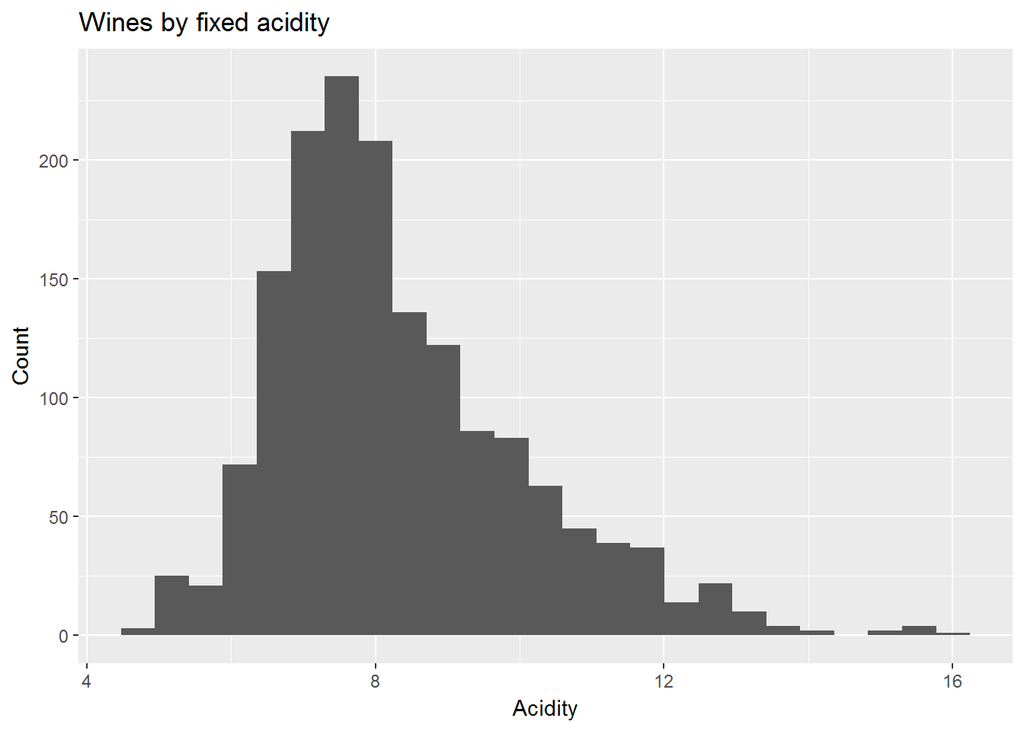

```
##    Min. 1st Qu.  Median    Mean 3rd Qu.    Max.
##    4.60    7.10    7.90    8.32    9.20   15.90
```

Distribution for fixed acidity is quite normally distributed with max occurrency at about 7.5.

#### Histograms for Volatile Acidity Density Distribution

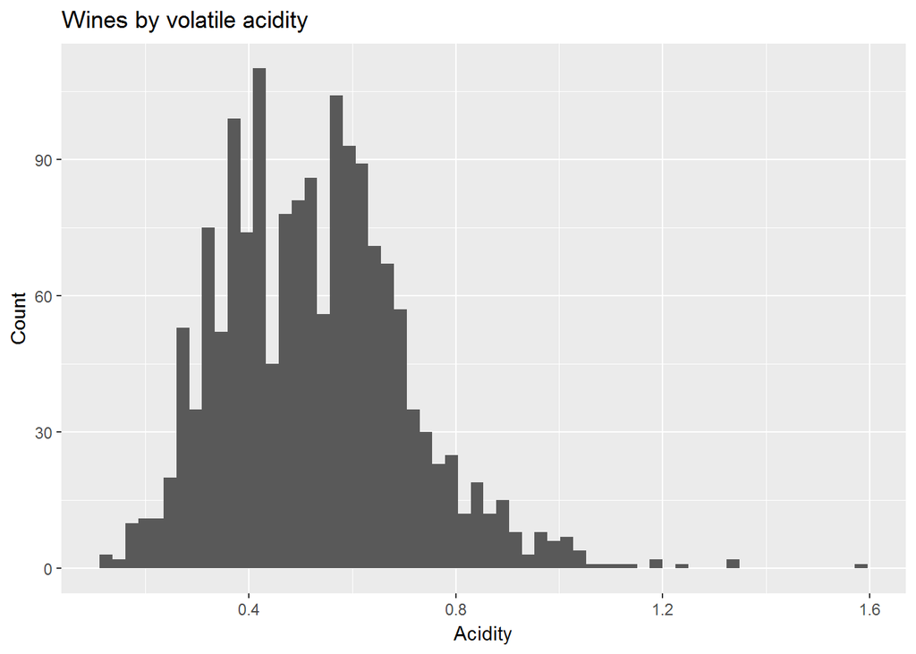

```
##    Min. 1st Qu.  Median    Mean 3rd Qu.    Max.
##  0.1200  0.3900  0.5200  0.5278  0.6400  1.5800
```

High quantities of volatile acids are a wine defect (undesirable aromas) which can not be reversed when wine is ready for tasting. Wine quality and volatile acidity can be expected to have a correlation.

#### Histogram for Citric Acid Distribution

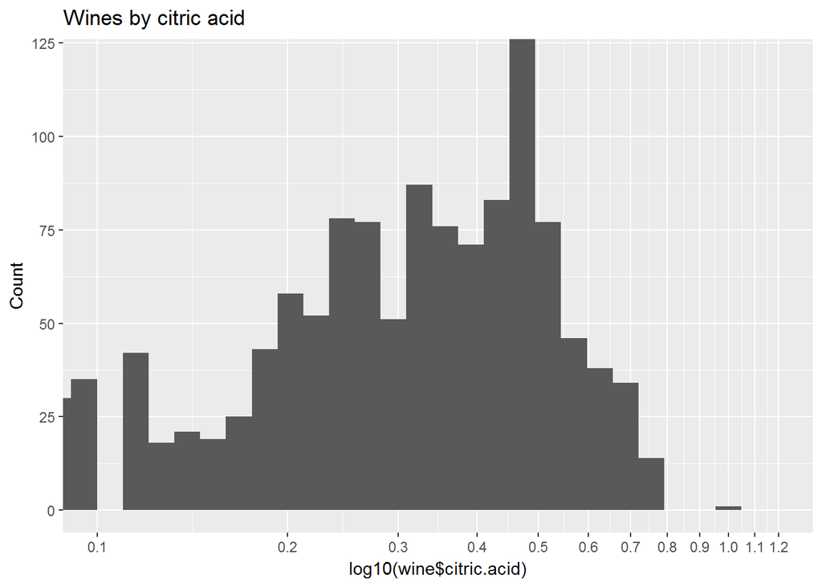

```
##    Min. 1st Qu.  Median    Mean 3rd Qu.    Max.
##   0.000   0.090   0.260   0.271   0.420   1.000
```

#### Histogram for Residual Sugar Distribution

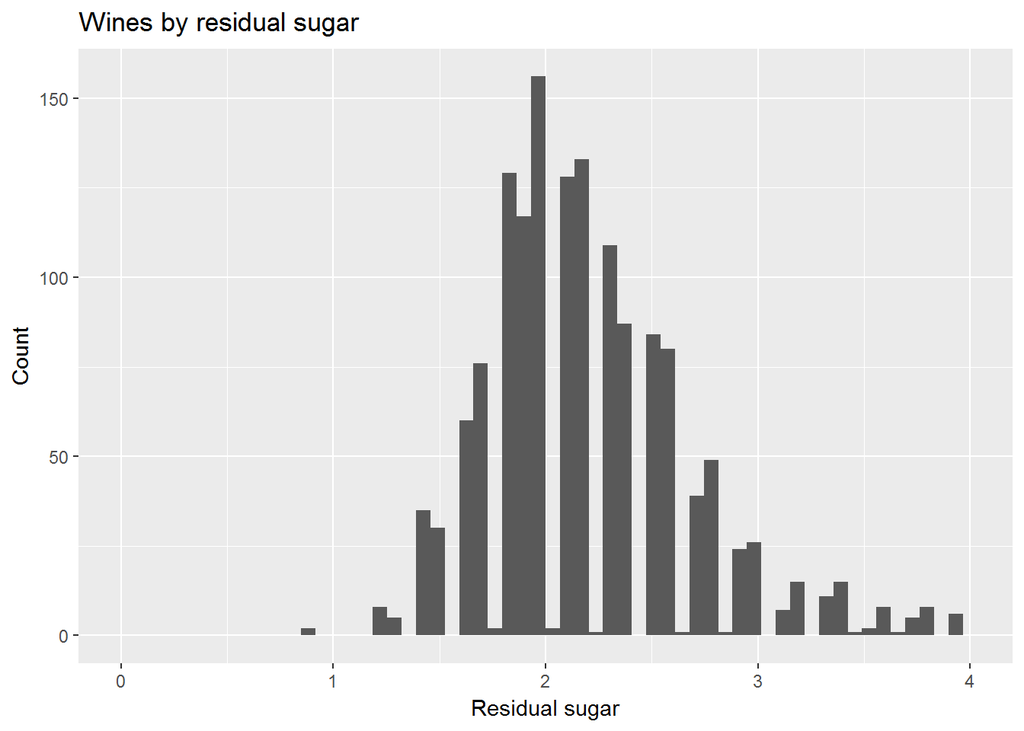

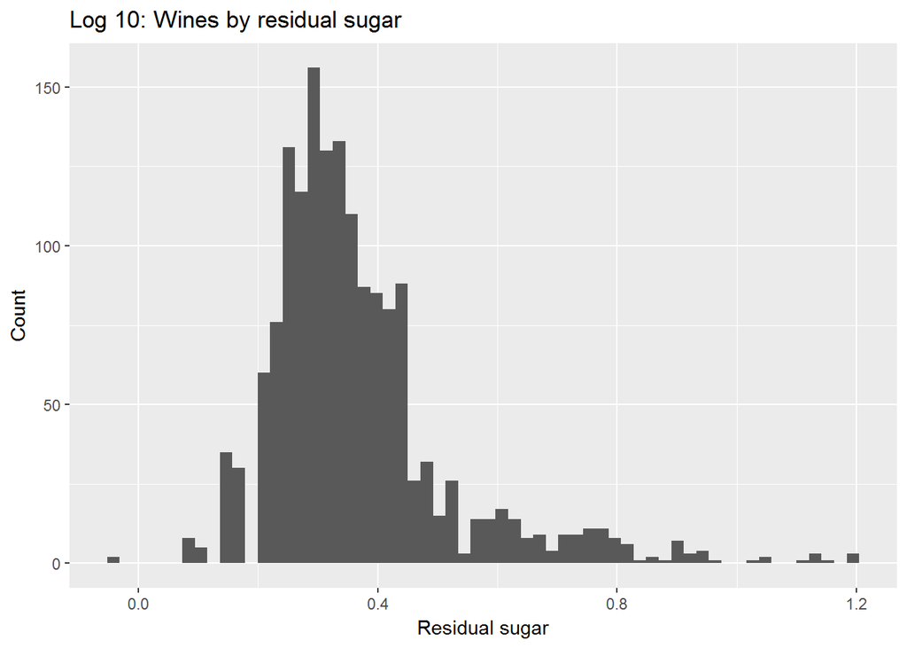

```
##    Min. 1st Qu.  Median    Mean 3rd Qu.    Max.
##   0.900   1.900   2.200   2.539   2.600  15.500
```

#### Histogram for chlorides Distribution

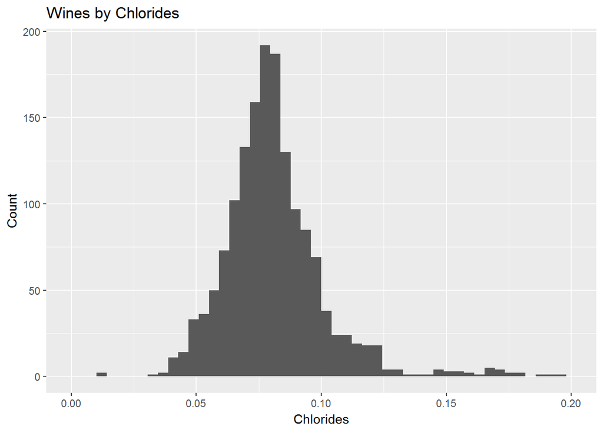

```
##    Min. 1st Qu.  Median    Mean 3rd Qu.    Max.
## 0.01200 0.07000 0.07900 0.08747 0.09000 0.61100
```

Chlorides in the wine ar normally distributed. As chlorides have an influence on taste (salty) we could expect a correllation to the wine quallity.

#### Histogram for Free Sulfur Dioxides Distribution

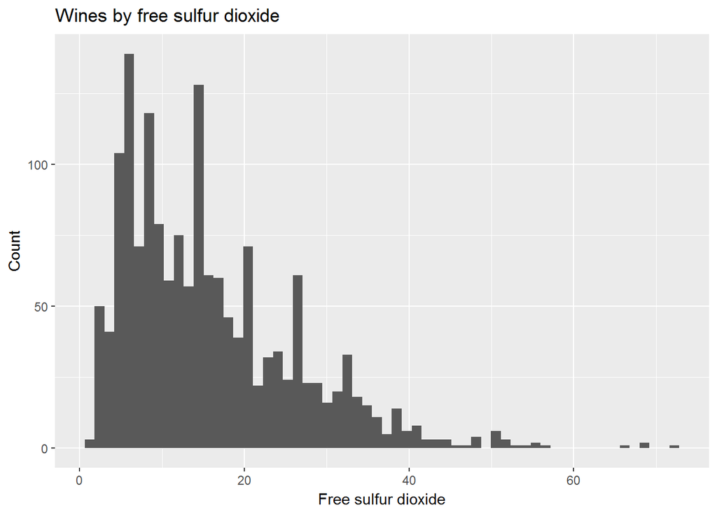

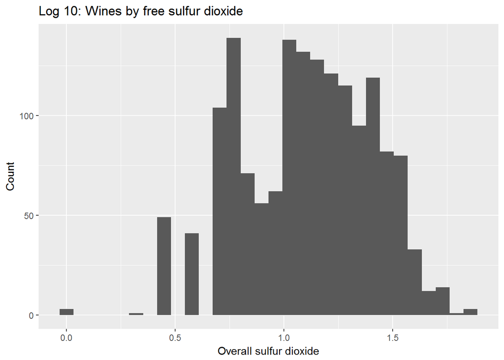

```
##    Min. 1st Qu.  Median    Mean 3rd Qu.    Max.
##    1.00    7.00   14.00   15.87   21.00   72.00
```

Also for the free sulfur dioxides we can see a more or less normal distribution when having applied a log10.

#### Histogram for total Sulfur Dioxides Distribution

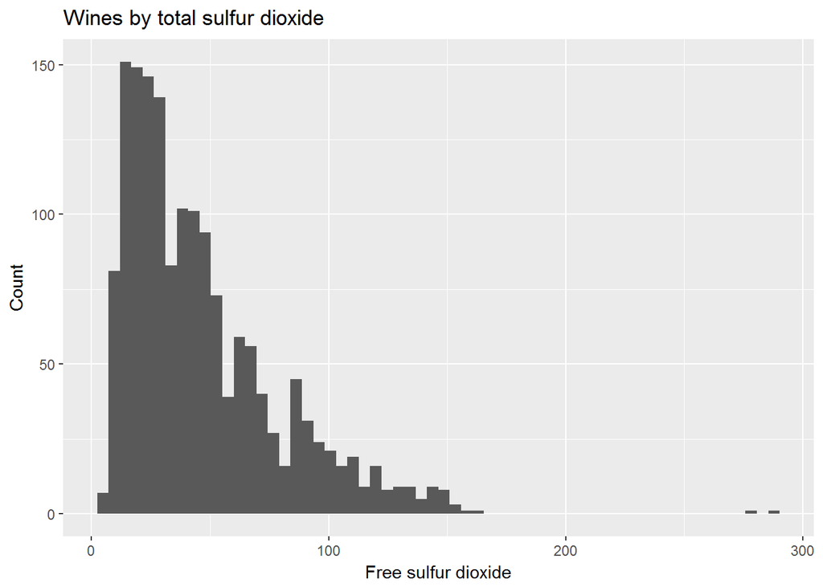

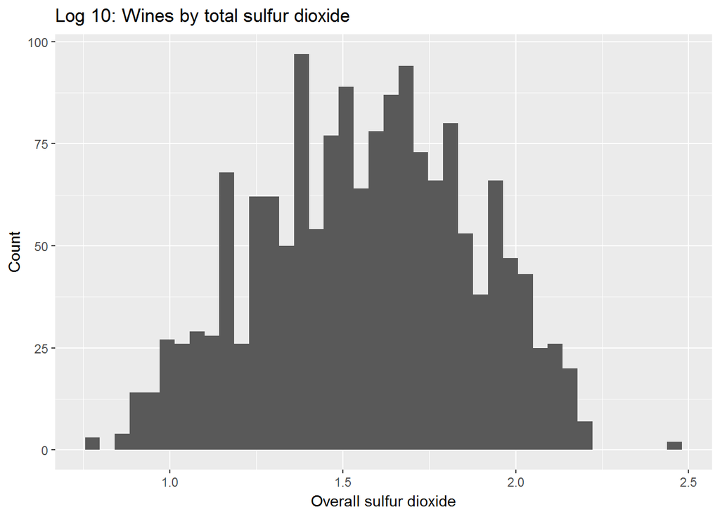

```
##    Min. 1st Qu.  Median    Mean 3rd Qu.    Max.
##    6.00   22.00   38.00   46.47   62.00  289.00
```

After log10 the total sulfur dioxides are quite normally distributed. Before we can see a strong positively skewed distribution.

#### Histogram for Density Distribution

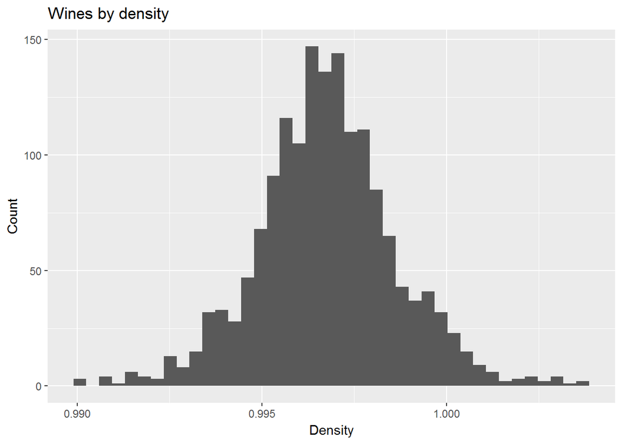

```
##    Min. 1st Qu.  Median    Mean 3rd Qu.    Max.
##  0.9901  0.9956  0.9968  0.9967  0.9978  1.0037
```

Density has a normal distribution with a maximum occurrency at 0.9968. Obviously ine has almost the same density as water (1.00).

#### Histograms for pH Distribution

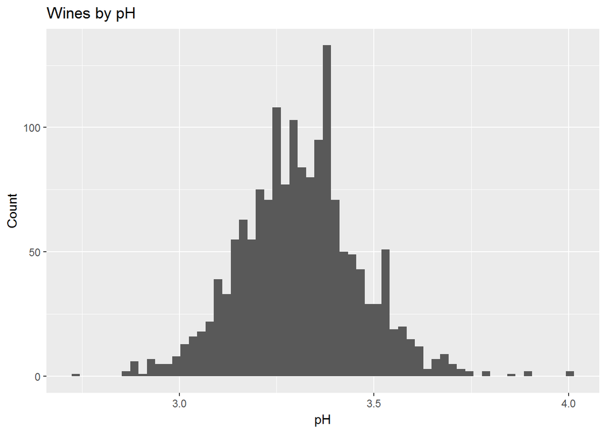

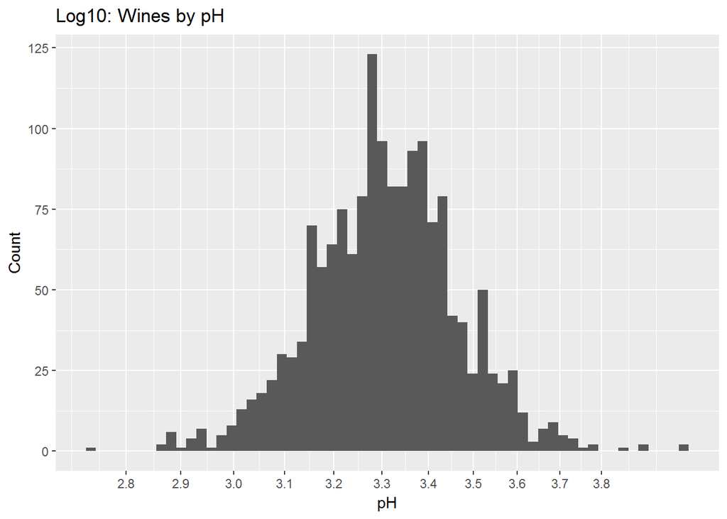

```
##    Min. 1st Qu.  Median    Mean 3rd Qu.    Max.
##   2.740   3.210   3.310   3.311   3.400   4.010
```

#### Histogram for Sulphates Distribution

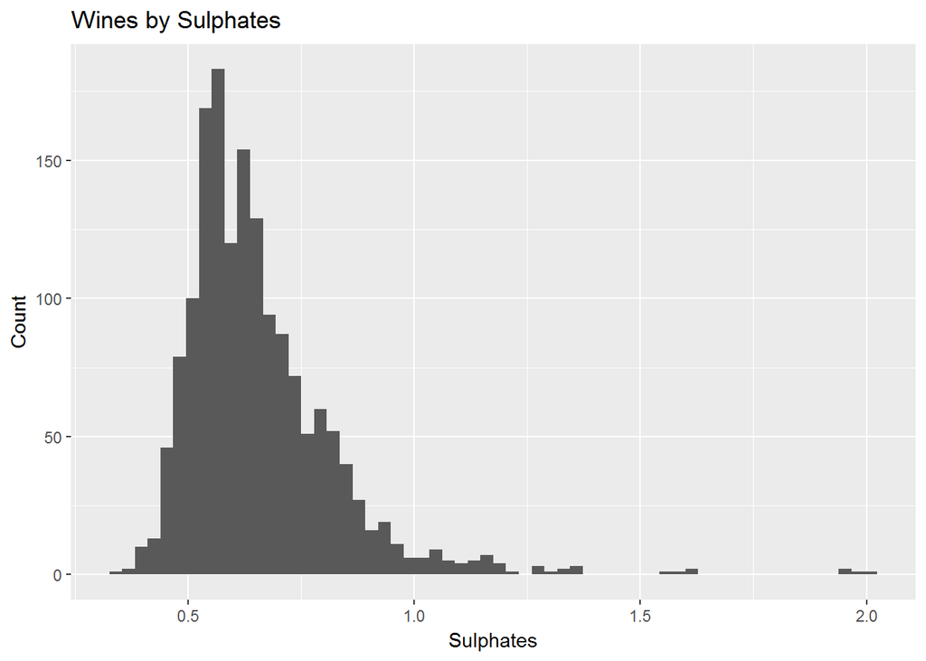

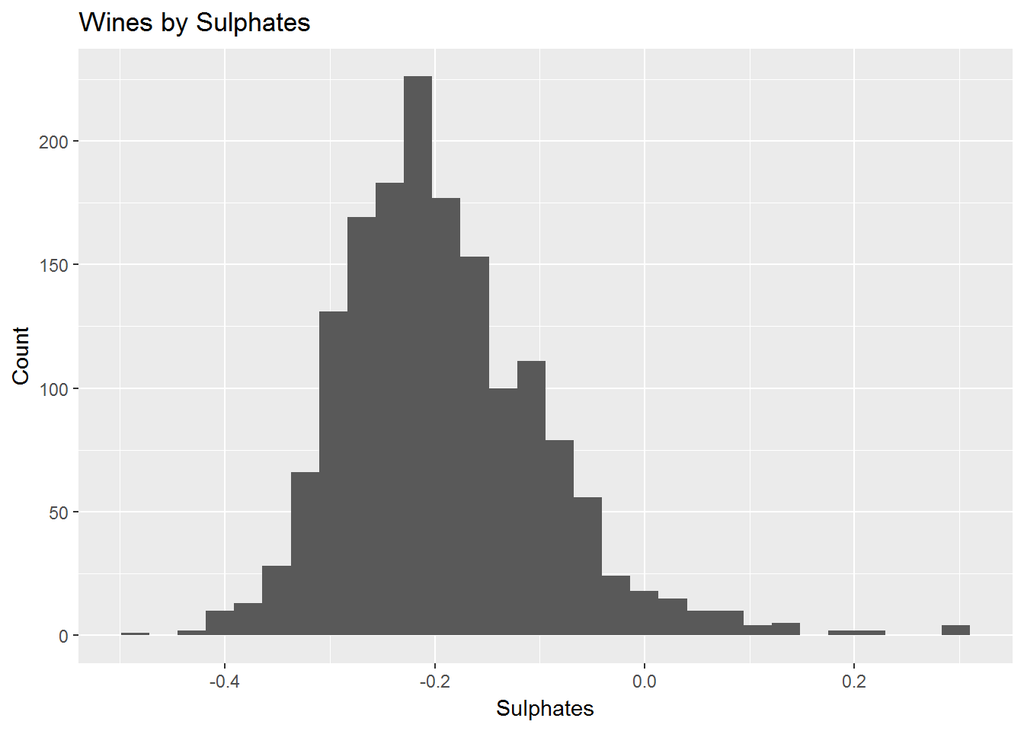

```
##    Min. 1st Qu.  Median    Mean 3rd Qu.    Max.
##  0.3300  0.5500  0.6200  0.6581  0.7300  2.0000
```

Sulphates are very important for the taste of wines. So we can expect that sulfates correllate to quality in any way. Depending on the sweetness of wine the amount of Sulphates can vary.

#### Histogram for Alcohol Distribution

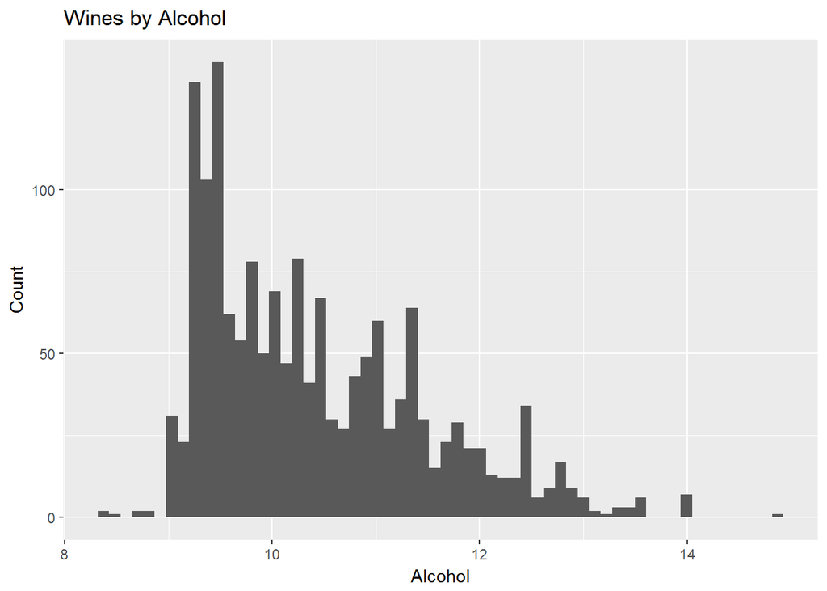

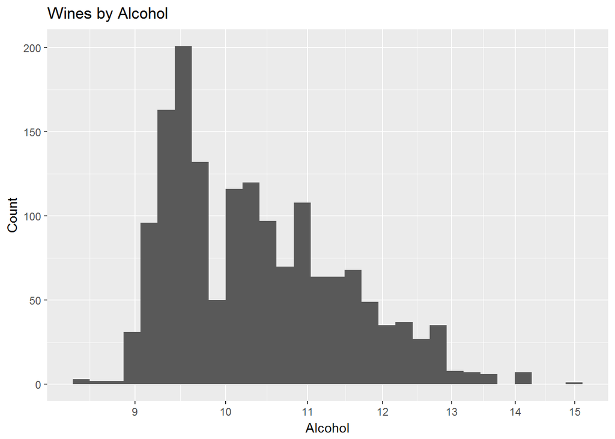

```
##    Min. 1st Qu.  Median    Mean 3rd Qu.    Max.
##    8.40    9.50   10.20   10.42   11.10   14.90
```

Log10-layer shows: Alcohol in the dataset is almost normally distributed and postivey skewed.

#### Histogram for Quality Distribution

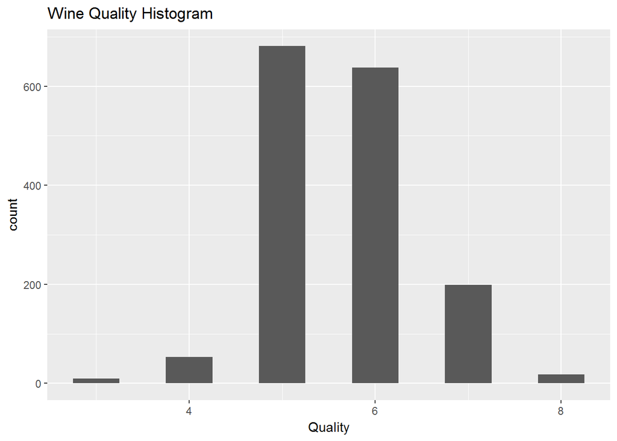

Quality ratings are distributed between 3 and 8 and have a slightly right skewed normal distribution.

## Analysis

#### What is the Structure of your Dataset?

-fixed.acidity  
-volatile.acidity  
-citric.acid  
-residual.sugar  
-chlorides  
-free.sulfur.dioxide  
-total.sulfur.dioxide  
-density  
-pH  
-sulphates  
-alcohol  
-quality

where “Quality” is a quantitative variable.  
Quality ratings range from values 3-8 (int), and are normally distributed.

#### What is/are the main feature(s) of interest in your dataset?

The main feature I am interested in is the “Quality”. I would like get a some evidence which variables are influencing the quality of wine. This will be done by a correllation analysis.  
From a business point of view this is important as a high-quality product can obtain higher prices.

#### Did you create any new variables from existing variables in your dataset?

I calculated the total acidity in the wines which is an important factor in combination with the sugar. Also in the next step I did the calculation of fixed sulfur dioxide and added a new column to the dataset.

```r
wine$total.acidity <- (wine$fixed.acidity + wine$volatile.acidity)
wine$fixed.sulfur.dioxide <- wine$total.sulfur.dioxide - wine$free.sulfur.dioxide
wine$ratio.sug.acid <- wine$residual.sugar / wine$total.acidity
```

#### What other features in the dataset do you think will support your investigation into your feature(s) of interest?

At first I need to get a feeling about correlation of several variables to the wine quality rating. I want to know how (and how strong) quality is being influence by the 11 other factors (or maybe combinaions of them). Correllation analysis will help to get the results I am interested in. This will be done in the next section.

#### Of the features you investigated were there any unusual distributions? Did you perform any operations on the data to tidy, adjust, or change the form of the data? If so why?

# Bivariate Section

## Bivariate Plots

#### Correllations Quality - others

Lets start with a visualisation of correllations which are related to quality.

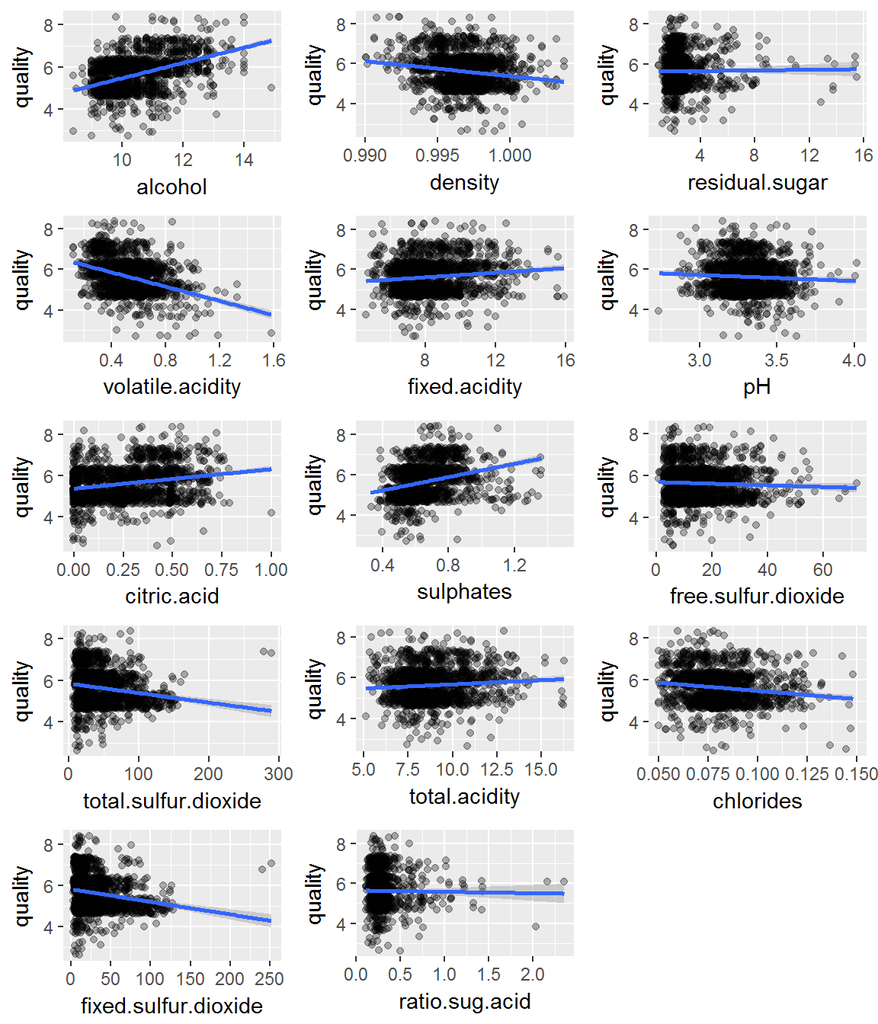

Best positive correlation to quality show:  
- Alcohol  
- Sulphates  
- Citric acid

Highest values for negative correlation:

- Chlorides
- Total sulfur dioxide
- Volatile acidity
- Density
- Fixed Sulfur Dioxide

For deeper investigation, let’s get definitve values for the correllation to alcohol and volatile acidity (appear as highest correlated values):

```
## [1] 0.4761663
```

```
## [1] -0.3905578
```

All other combinations with quality are less correllated and will not be regarded.

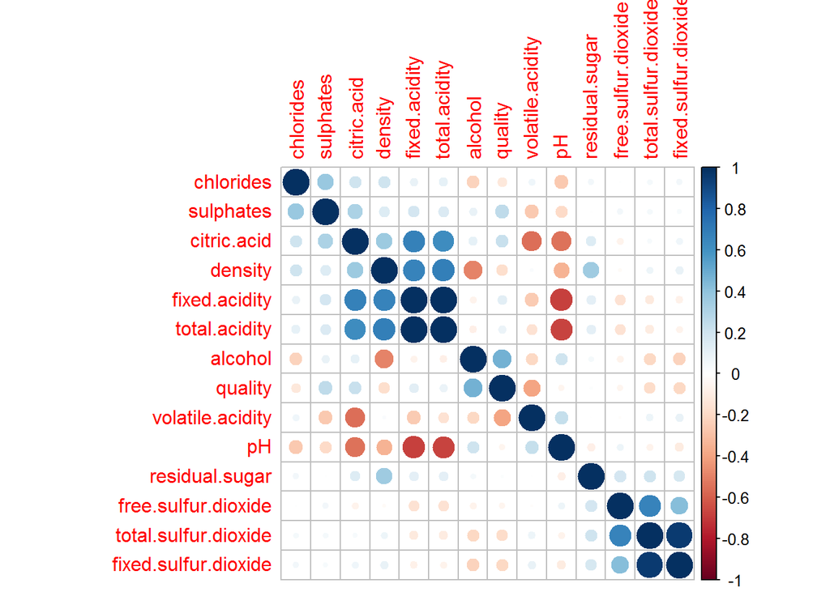

Based on the correlation matrix I tried to find some more out about correllation of some pairs which seem interesting to me:

- Density - Fixed Acidity
- pH - Total acidity
- Density - Alcohol
- Citric Acid - Volatile Acidity

At first define a function for reuse:

Now let’s have a look at the pairs:

#### Density - Fixed Acidity

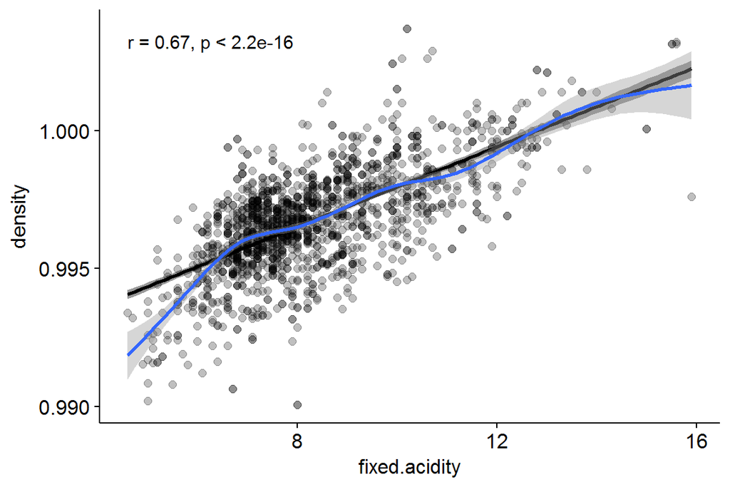

```
## [1] 0.6680473
```

Fixed acidity and density values have a correllation of 0.6680473.

#### pH - Total Acidity

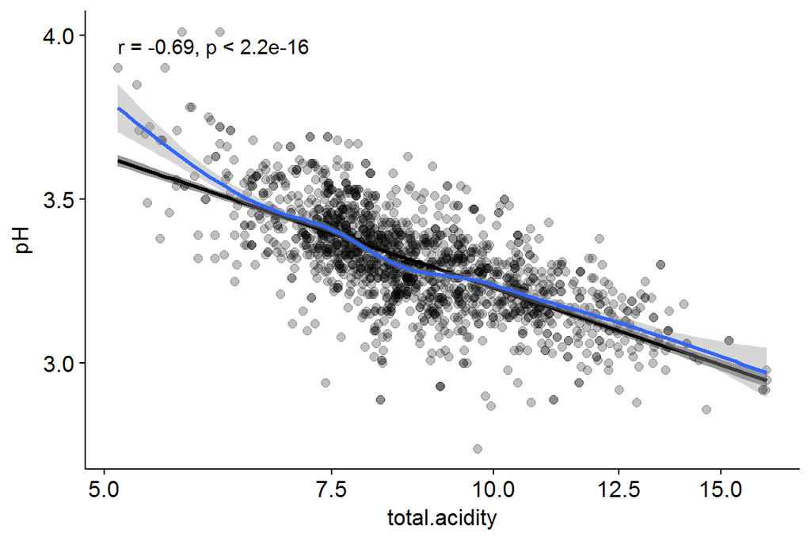

```
## [1] -0.6918566
```

Total Acidity and pH have a correllation of -0.6918566.

#### Density - Alcohol

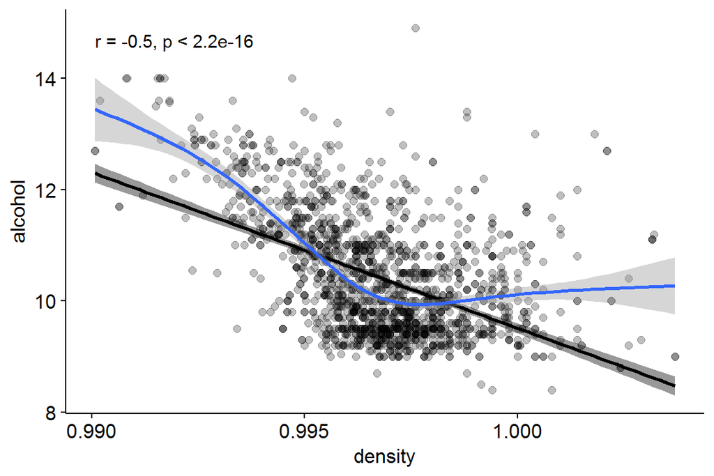

```
## [1] -0.4961798
```

#### Citric Acid - Volatile Acidity

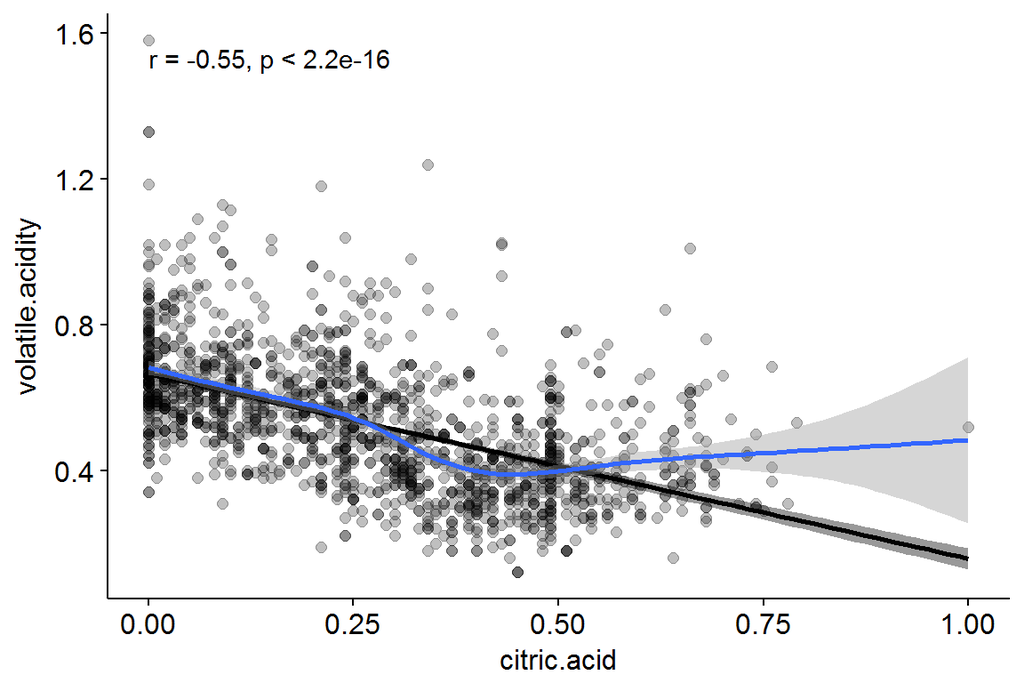

```
## [1] -0.5524957
```

The correllation between citric acid and volatile acidity is -0.5524957.

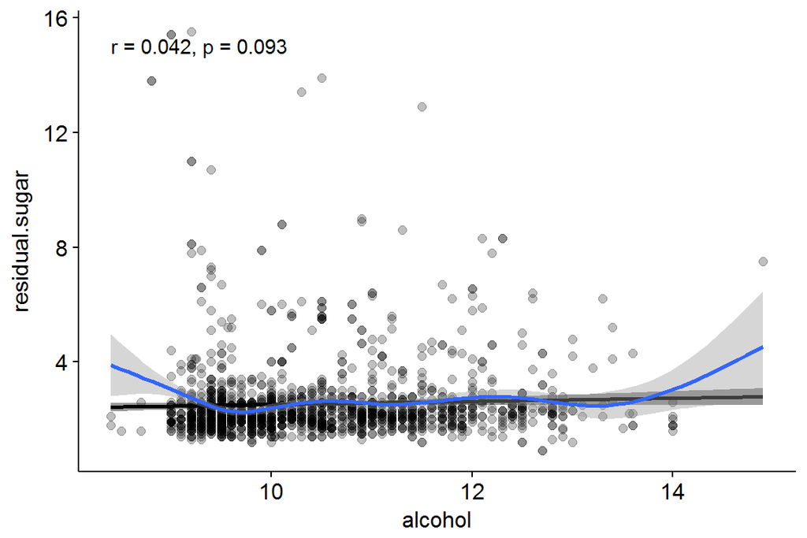

```
## [1] 0.04207544
```

Alcohol and residual sugar have a correllation of 0.04207544.

## Bivariate Analysis

#### Did you observe any other intresting relationships between the other features (not the main feature of intrest)?

Residual sugar appears only weakly correlated with alcohol level. I expected a higher correllation.  
My thought was, that wines with a high content of alcohol have less residual sugar due to alcoholic fermentation process.

#### What was the strongest relationship you found?

The strongest correlation I found out was pH vs total Acidity. This is due to the definition of pH value which indicates the the acidity / basicity of an aeqous solution (https://en.wikipedia.org/wiki/PH).

# Multivariate Section

A good basis for the multivariate section is the corrplot from bivariate analysis.  
In addition to some wine know how we can start plotting some values which are considered to be related.

## Multivariate Plots

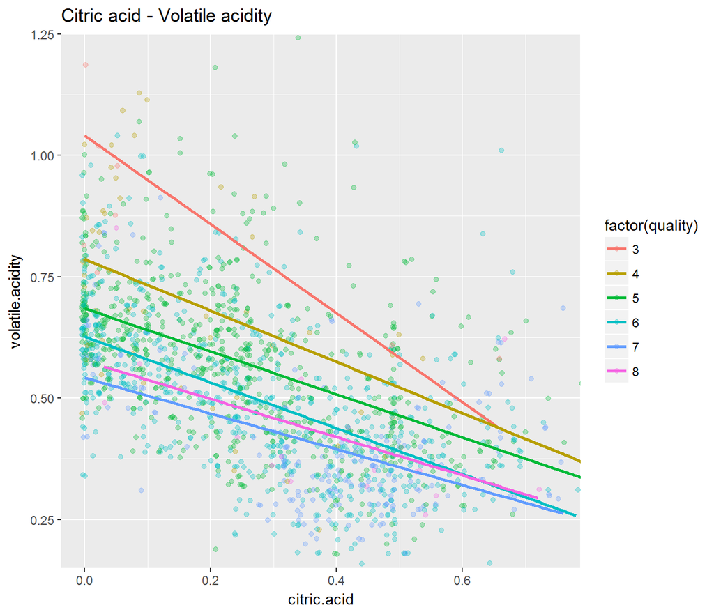

Low volatile acidity and high citric acid values are related to high quality wines. For lower rated wines the trend is vce versa (high volatile acidity - low citric acid).

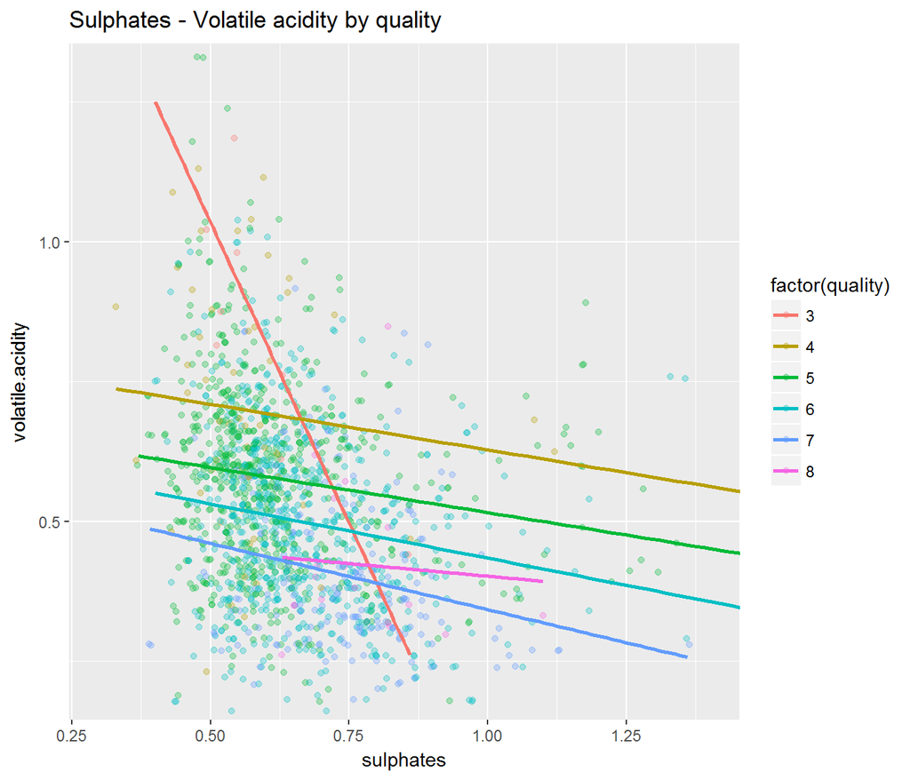

Low volatile acidity and high sulphates are related to high quality wines. For lower rated wines the trend is vce versa (high volatile acidity - low sulphates).

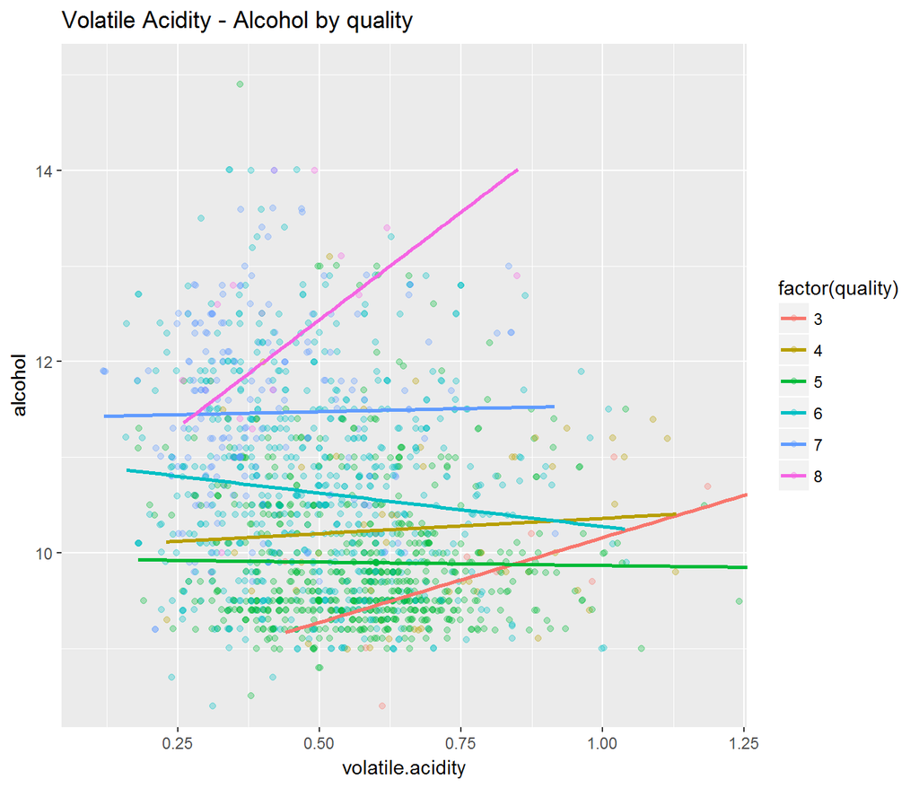

Highly rated wines lower volatile acidity but more alcohol whereas lower rated wines tend to have high volatile acidity and less alcohol.

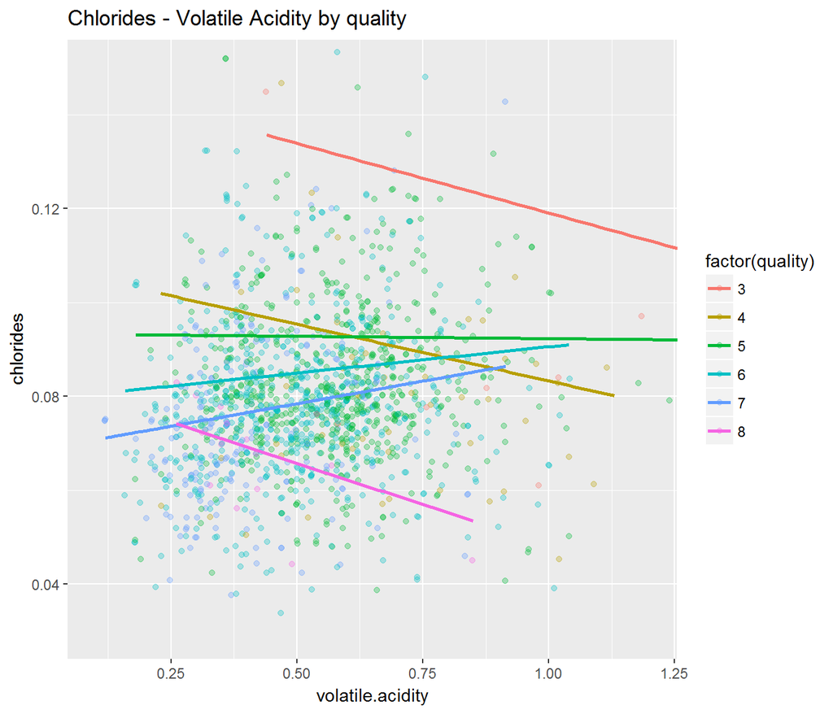

Low volatile acidity and low chlorides re related to high quality ratings; low quality ratings basically have higher volatile acidity and higher chloride values.

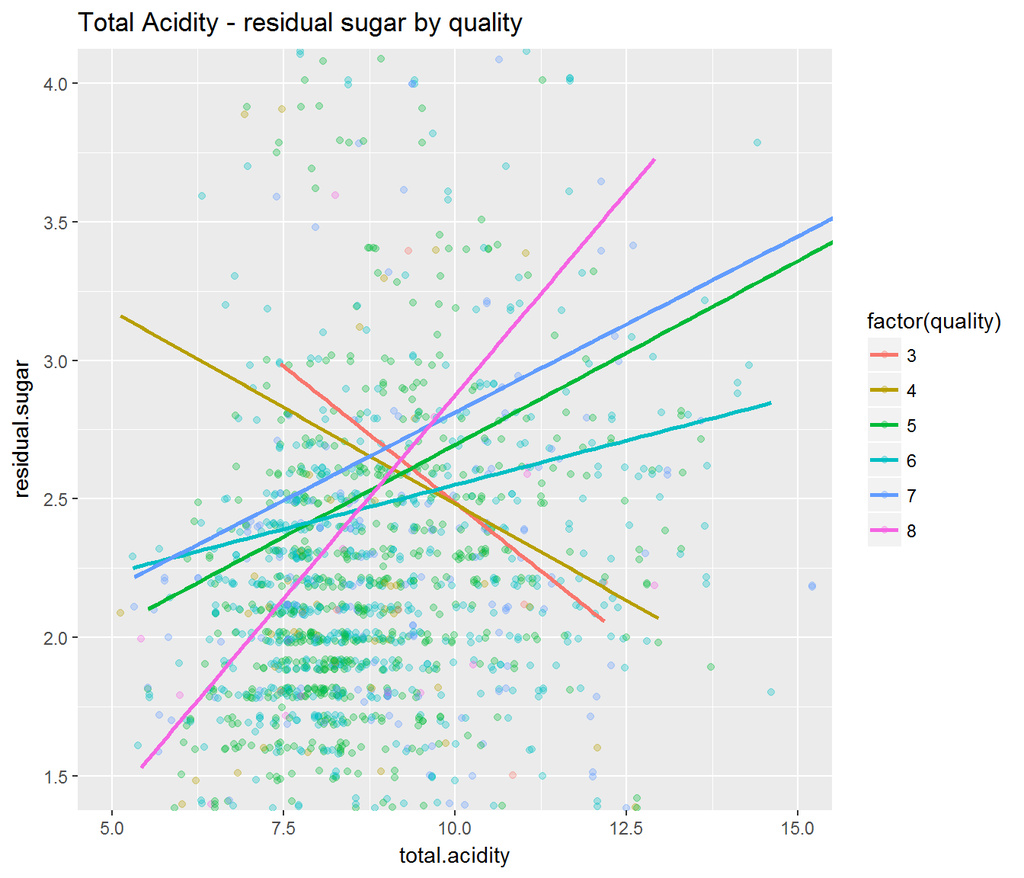

Fixed acidity is influencing density more than alohol.

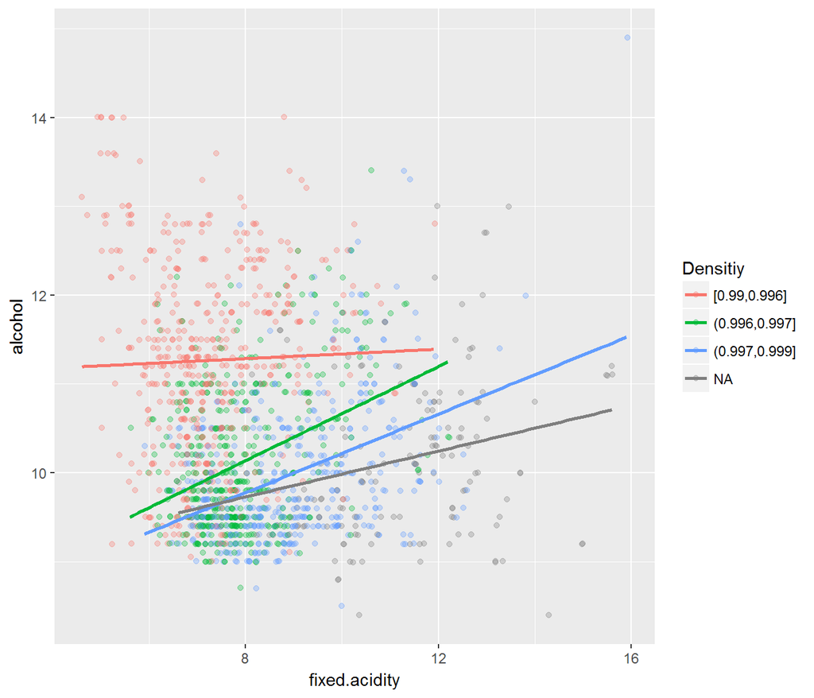

```
## $title
## [1] "Fixed Acidity - alcohol by density"
##
## $subtitle
## NULL
##
## attr(,"class")
## [1] "labels"
```